# RTEAnalytics-Sergey-01.Rmd

Sergey Efimenko

29 Jan 2016

## Part 1 - Analysys of French Energy System.

Given the nature of the data the analysis will focuse on the following issues: 1. Understanding of correlations between consumption, generation mix, CO2 emissions, net export, time of the day and season. 2. If correlation is traced and can be explained the next step is to use linear regression models to describe the relationship between dependent and independent variables.

## Part 2 - Correlation matrix analysis

We used R programming language tools to construct correlation matrix for the parameters selected from the raw dataset. For better visualisation we used “Corrplot” package, that can let us trace dependencies in a convenient way. We decided to exclude from analysis the correlation coefficients that are not significant under p = 0,05. Such cells are left blank in the following diagramm:

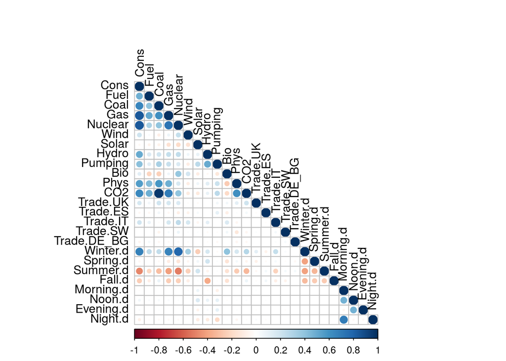

The correlation between consumption and generation mix seems obvious since power stations produce electricity according to the current demand load in the system. We decided not to construct the model for this relationship since similar analysis is provided in the energy mix table. Instead, we decided to futher investigate relationships from point 2 to 5.

*Regression of consumption vc the season of the year* To find the relationship between consumption of the energy and the season we assumed that Intercept will represent consumption in Fall and used other seasons are either 1 or 0. The results of regression are the following:

$Consumption = 4.7916\times 10^{4} + -3457*Summer +6055*Spring +1.8877\times 10^{4}*Winter$

*Regression of Solar energy generation vc the season* To find the relationship between solar energy generation and the season we assumed that Intercept will represent generation in Fall and used other seasons are either 1 or 0. The results of regression are the following:

$Solar_generation = 571 + 235*Summer +46*Spring +-315*Winter$

*Regression of Wind energy generation vc the season* To find the relationship between wind energy generation and the season we assumed that Intercept will represent generation in Fall and used other seasons are either 1 or 0. The results of regression are the following:

$Wind_generation = 1555 + -277*Summer +163*Spring +891*Winter$